# Getting Started

Your First Fire Simulation with Elmfire.jl

This tutorial will guide you through running your first wildfire simulation with Elmfire.jl. We’ll cover the basic components and build up to more complex scenarios with visualizations.

## Setup

First, let’s load the required packages:

```julia
using Elmfire
using Plots
using Random

# Set a seed for reproducibility
Random.seed!(42)
```

```
TaskLocalRNG()
```

## Understanding the Components

A fire simulation in Elmfire.jl requires several components:

1. **FireState** - The simulation grid that tracks fire spread
2. **FuelModelTable** - Lookup table of fuel properties
3. **Weather** - Wind speed, direction, and fuel moisture
4. **Terrain** - Slope and aspect (optional for flat terrain)

Let’s explore each component.

## Basic Simulation: Flat Terrain, No Wind

Let’s start with the simplest case - a fire spreading on flat terrain with no wind:

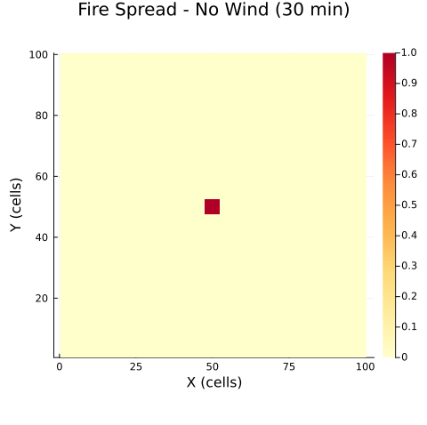

```julia
# Create a 100x100 grid with 30-foot cells
ncols, nrows = 100, 100
cellsize = 30.0  # feet

state = FireState{Float64}(ncols, nrows, cellsize)

# Create fuel model table with standard fuel models
fuel_table = create_standard_fuel_table(Float64)

# Weather with NO wind
weather_no_wind = ConstantWeather{Float64}(
    wind_speed_mph = 0.0,
    wind_direction = 0.0,
    M1 = 0.06,   # 6% moisture for 1-hr fuels
    M10 = 0.08,
    M100 = 0.10,
    MLH = 0.60,
    MLW = 0.90
)

# Ignite at the center
ignite!(state, 50, 50, 0.0)

# Run simulation for 30 minutes
simulate_uniform!(
    state,
    1,              # FBFM01 (Short grass)
    fuel_table,
    weather_no_wind,
    0.0,            # Flat terrain (0 degrees slope)
    0.0,            # Aspect doesn't matter when flat
    0.0,            # Start time
    30.0            # End time (30 minutes)
)

# Visualize the burned area
heatmap(
    state.burned',
    title = "Fire Spread - No Wind (30 min)",
    xlabel = "X (cells)",
    ylabel = "Y (cells)",
    color = :YlOrRd,
    aspect_ratio = 1,
    size = (500, 500)
)
```

## Adding Wind: Elliptical Fire Spread

Now let’s add wind and see how it changes the fire shape:

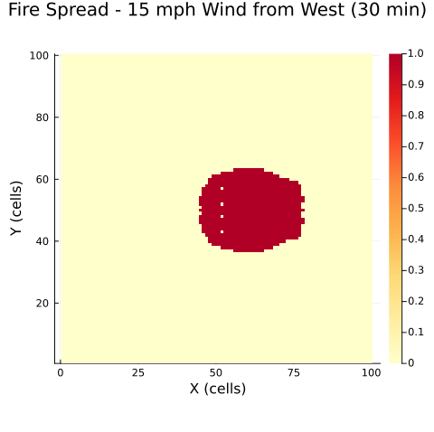

```julia
# Reset the state
state = FireState{Float64}(ncols, nrows, cellsize)

# Weather WITH wind from the west (blowing east)
weather_wind = ConstantWeather{Float64}(
    wind_speed_mph = 15.0,
    wind_direction = 270.0,  # Wind FROM west
    M1 = 0.06,
    M10 = 0.08,
    M100 = 0.10,
    MLH = 0.60,
    MLW = 0.90
)

# Ignite at center
ignite!(state, 50, 50, 0.0)

# Run simulation
simulate_uniform!(state, 1, fuel_table, weather_wind, 0.0, 0.0, 0.0, 30.0)

# Visualize
heatmap(
    state.burned',
    title = "Fire Spread - 15 mph Wind from West (30 min)",
    xlabel = "X (cells)",
    ylabel = "Y (cells)",
    color = :YlOrRd,
    aspect_ratio = 1,
    size = (500, 500)
)
```

The fire now spreads in an **elliptical pattern**, moving much faster downwind (to the east) than upwind.

## Comparing Wind Speeds

Let’s compare how different wind speeds affect fire spread:

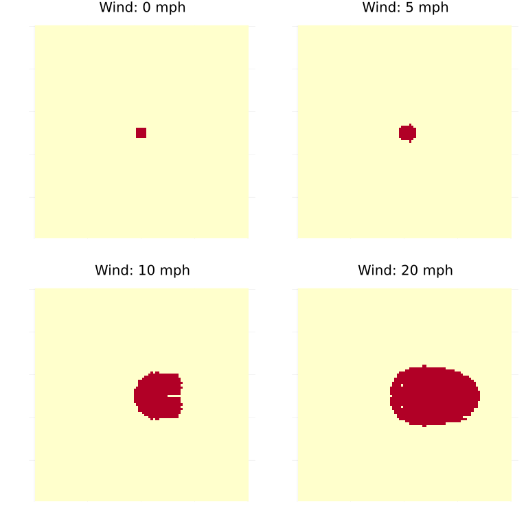

```julia
wind_speeds = [0, 5, 10, 20]
plots_wind = []

for ws in wind_speeds
    state = FireState{Float64}(ncols, nrows, cellsize)

    weather = ConstantWeather{Float64}(
        wind_speed_mph = Float64(ws),
        wind_direction = 270.0,
        M1 = 0.06, M10 = 0.08, M100 = 0.10,
        MLH = 0.60, MLW = 0.90
    )

    ignite!(state, 50, 50, 0.0)
    simulate_uniform!(state, 1, fuel_table, weather, 0.0, 0.0, 0.0, 30.0)

    p = heatmap(
        state.burned',
        title = "Wind: $ws mph",
        color = :YlOrRd,
        aspect_ratio = 1,
        colorbar = false,
        axis = false
    )
    push!(plots_wind, p)
end

plot(plots_wind..., layout = (2, 2), size = (800, 800))
```

As wind speed increases:

- Fire spread becomes more **elliptical**
- The **head fire** (downwind) moves much faster
- The **backing fire** (upwind) moves very slowly
- Total burned area increases significantly

## Effect of Wind Direction

Let’s see how wind direction affects the fire spread pattern:

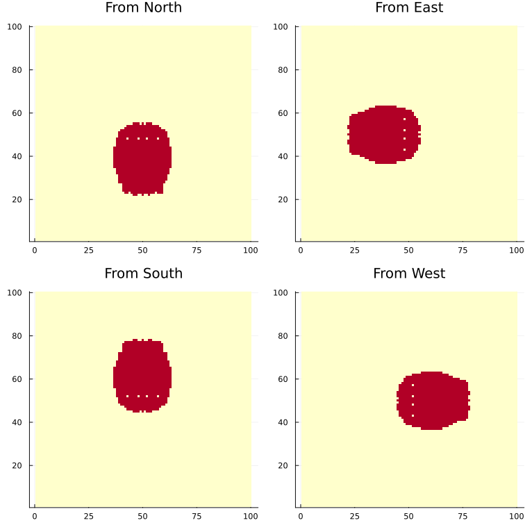

```julia
wind_directions = [0, 90, 180, 270]  # N, E, S, W
direction_labels = ["From North", "From East", "From South", "From West"]
plots_dir = []

for (wd, label) in zip(wind_directions, direction_labels)
    state = FireState{Float64}(ncols, nrows, cellsize)

    weather = ConstantWeather{Float64}(
        wind_speed_mph = 15.0,
        wind_direction = Float64(wd),
        M1 = 0.06, M10 = 0.08, M100 = 0.10,
        MLH = 0.60, MLW = 0.90
    )

    ignite!(state, 50, 50, 0.0)
    simulate_uniform!(state, 1, fuel_table, weather, 0.0, 0.0, 0.0, 30.0)

    p = heatmap(
        state.burned',
        title = label,
        color = :YlOrRd,
        aspect_ratio = 1,
        colorbar = false
    )
    push!(plots_dir, p)
end

plot(plots_dir..., layout = (2, 2), size = (800, 800))
```

## Fuel Moisture Effects

Fuel moisture is critical to fire behavior. Drier fuels burn more intensely:

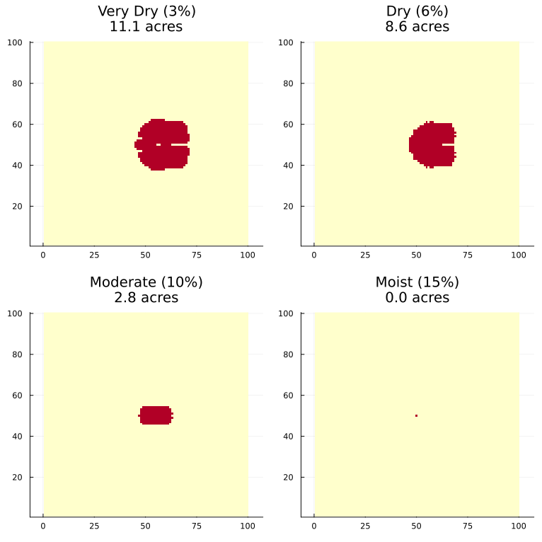

```julia
moisture_levels = [(0.03, "Very Dry (3%)"), (0.06, "Dry (6%)"),
                   (0.10, "Moderate (10%)"), (0.15, "Moist (15%)")]
plots_moisture = []

for (m1, label) in moisture_levels
    state = FireState{Float64}(ncols, nrows, cellsize)

    weather = ConstantWeather{Float64}(
        wind_speed_mph = 10.0,
        wind_direction = 270.0,
        M1 = m1,
        M10 = m1 + 0.02,
        M100 = m1 + 0.04,
        MLH = 0.60,
        MLW = 0.90
    )

    ignite!(state, 50, 50, 0.0)
    simulate_uniform!(state, 1, fuel_table, weather, 0.0, 0.0, 0.0, 30.0)

    acres = get_burned_area_acres(state)
    p = heatmap(
        state.burned',
        title = "$label\n$(round(acres, digits=1)) acres",
        color = :YlOrRd,
        aspect_ratio = 1,
        colorbar = false
    )
    push!(plots_moisture, p)
end

plot(plots_moisture..., layout = (2, 2), size = (800, 800))
```

Lower fuel moisture = faster spread and more area burned!

## Different Fuel Types

The fuel model dramatically affects fire behavior. Let’s compare a few standard fuel models:

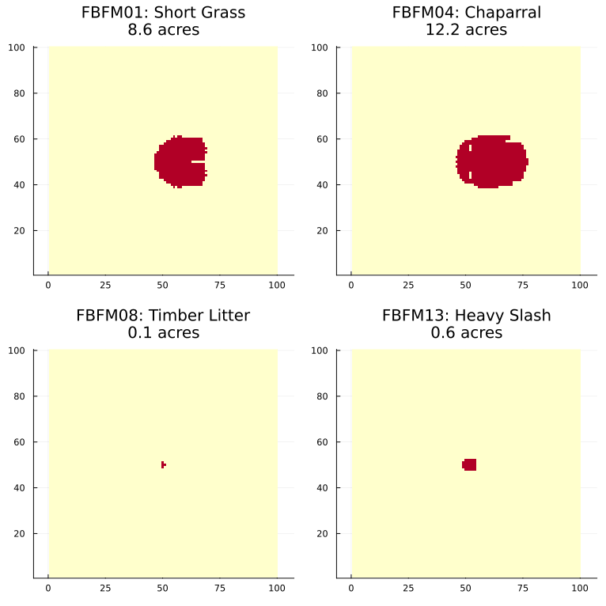

```julia
fuel_models = [
    (1, "FBFM01: Short Grass"),
    (4, "FBFM04: Chaparral"),
    (8, "FBFM08: Timber Litter"),
    (13, "FBFM13: Heavy Slash")
]
plots_fuel = []

for (fuel_id, label) in fuel_models
    state = FireState{Float64}(ncols, nrows, cellsize)

    weather = ConstantWeather{Float64}(
        wind_speed_mph = 10.0,
        wind_direction = 270.0,
        M1 = 0.06, M10 = 0.08, M100 = 0.10,
        MLH = 0.60, MLW = 0.90
    )

    ignite!(state, 50, 50, 0.0)
    simulate_uniform!(state, fuel_id, fuel_table, weather, 0.0, 0.0, 0.0, 30.0)

    acres = get_burned_area_acres(state)
    p = heatmap(
        state.burned',
        title = "$label\n$(round(acres, digits=1)) acres",
        color = :YlOrRd,
        aspect_ratio = 1,
        colorbar = false
    )
    push!(plots_fuel, p)
end

plot(plots_fuel..., layout = (2, 2), size = (800, 800))
```

Each fuel model has different:

- **Fuel loading** (amount of fuel)
- **Surface area to volume ratio** (how quickly it burns)
- **Fuel bed depth** (affects wind adjustment)
- **Moisture of extinction** (how wet it can be and still burn)

## Terrain Effects: Slope

Fire spreads faster uphill. Let’s compare different slopes:

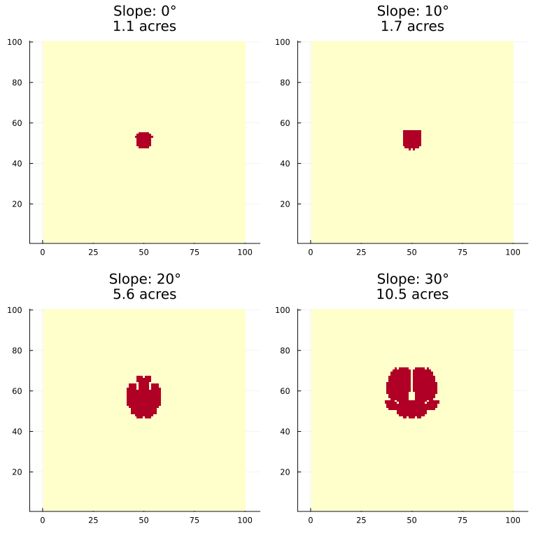

```julia
slopes = [0, 10, 20, 30]  # degrees
plots_slope = []

for slp in slopes
    state = FireState{Float64}(ncols, nrows, cellsize)

    weather = ConstantWeather{Float64}(
        wind_speed_mph = 5.0,
        wind_direction = 180.0,  # From south
        M1 = 0.06, M10 = 0.08, M100 = 0.10,
        MLH = 0.60, MLW = 0.90
    )

    ignite!(state, 50, 50, 0.0)

    # Uphill to the north (aspect = 180 means slope faces south)
    simulate_uniform!(state, 1, fuel_table, weather, Float64(slp), 180.0, 0.0, 30.0)

    acres = get_burned_area_acres(state)
    p = heatmap(
        state.burned',
        title = "Slope: $(slp)°\n$(round(acres, digits=1)) acres",
        color = :YlOrRd,
        aspect_ratio = 1,
        colorbar = false
    )
    push!(plots_slope, p)
end

plot(plots_slope..., layout = (2, 2), size = (800, 800))
```

Steeper slopes cause faster uphill spread due to:

- Preheating of uphill fuels by convection
- Flames directly contacting uphill fuels
- Increased effective wind (draft effect)

## Time of Arrival Map

The `time_of_arrival` field shows when each cell burned:

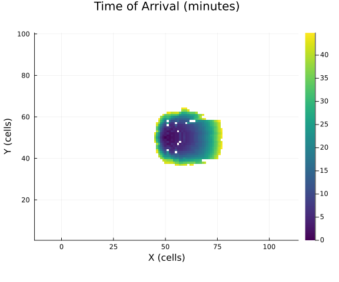

```julia
state = FireState{Float64}(ncols, nrows, cellsize)

weather = ConstantWeather{Float64}(
    wind_speed_mph = 12.0,
    wind_direction = 270.0,
    M1 = 0.06, M10 = 0.08, M100 = 0.10,
    MLH = 0.60, MLW = 0.90
)

ignite!(state, 50, 50, 0.0)
simulate_uniform!(state, 1, fuel_table, weather, 0.0, 0.0, 0.0, 45.0)

# Replace -1 (unburned) with NaN for plotting
toa = copy(state.time_of_arrival)
toa[toa .< 0] .= NaN

heatmap(
    toa',
    title = "Time of Arrival (minutes)",
    xlabel = "X (cells)",
    ylabel = "Y (cells)",
    color = :viridis,
    aspect_ratio = 1,
    size = (600, 500)
)
```

The time of arrival map is useful for:

- Evacuation planning
- Resource deployment timing
- Understanding fire progression

## Fireline Intensity

Fireline intensity (kW/m) indicates fire severity:

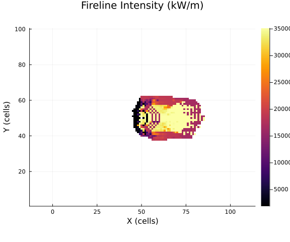

```julia
state = FireState{Float64}(ncols, nrows, cellsize)

weather = ConstantWeather{Float64}(
    wind_speed_mph = 15.0,
    wind_direction = 270.0,
    M1 = 0.04, M10 = 0.06, M100 = 0.08,
    MLH = 0.50, MLW = 0.80
)

ignite!(state, 50, 50, 0.0)
simulate_uniform!(state, 4, fuel_table, weather, 5.0, 180.0, 0.0, 30.0)  # Chaparral on slope

# Plot fireline intensity
flin = copy(state.fireline_intensity)
flin[flin .== 0] .= NaN

heatmap(
    flin',
    title = "Fireline Intensity (kW/m)",
    xlabel = "X (cells)",
    ylabel = "Y (cells)",
    color = :inferno,
    aspect_ratio = 1,
    size = (600, 500)
)
```

Fireline intensity classifications:

- **< 350 kW/m**: Low intensity, hand crews can work directly
- **350-1700 kW/m**: Moderate, mechanical equipment needed
- **1700-3500 kW/m**: High, aerial support required
- **> 3500 kW/m**: Very high, control very difficult

## Fire Progression Over Time

Let’s visualize how a fire grows over time:

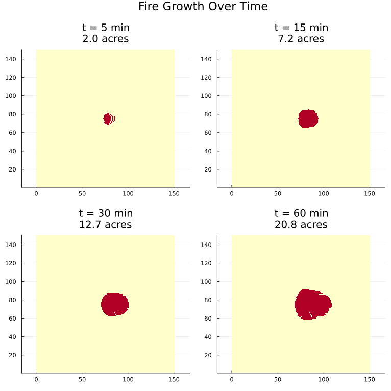

```julia
times = [5, 15, 30, 60]
plots_time = []

for t_end in times
    state = FireState{Float64}(150, 150, cellsize)

    weather = ConstantWeather{Float64}(
        wind_speed_mph = 12.0,
        wind_direction = 270.0,
        M1 = 0.05, M10 = 0.07, M100 = 0.09,
        MLH = 0.55, MLW = 0.85
    )

    ignite!(state, 75, 75, 0.0)
    simulate_uniform!(state, 1, fuel_table, weather, 0.0, 0.0, 0.0, Float64(t_end))

    acres = get_burned_area_acres(state)
    p = heatmap(
        state.burned',
        title = "t = $t_end min\n$(round(acres, digits=1)) acres",
        color = :YlOrRd,
        aspect_ratio = 1,
        colorbar = false
    )
    push!(plots_time, p)
end

plot(plots_time..., layout = (2, 2), size = (800, 800),
     plot_title = "Fire Growth Over Time")
```

## Multiple Ignition Points

You can simulate fires with multiple ignition points:

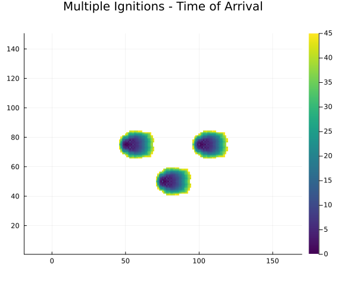

```julia
state = FireState{Float64}(150, 150, cellsize)

weather = ConstantWeather{Float64}(
    wind_speed_mph = 8.0,
    wind_direction = 270.0,
    M1 = 0.06, M10 = 0.08, M100 = 0.10,
    MLH = 0.60, MLW = 0.90
)

# Multiple ignition points
ignite!(state, 50, 75, 0.0)
ignite!(state, 100, 75, 5.0)  # 5 minutes later
ignite!(state, 75, 50, 10.0)  # 10 minutes later

simulate_uniform!(state, 1, fuel_table, weather, 0.0, 0.0, 0.0, 45.0)

# Show time of arrival to see fire merger
toa = copy(state.time_of_arrival)
toa[toa .< 0] .= NaN

heatmap(
    toa',
    title = "Multiple Ignitions - Time of Arrival",
    color = :viridis,
    aspect_ratio = 1,
    size = (600, 500)
)
```

## What’s Next?

Now that you understand the basics, explore more advanced topics:

- **Weather Effects** - Time-varying weather
- **Crown Fire** - Active and passive crown fire
- **Spotting** - Ember transport and spot fires
- **Ensemble Simulations** - Probabilistic forecasting
- **WUI Modeling** - Building ignition
- **Suppression** - Fire containment